# How to prepare scanem input using a scATAC-seq dataset

## Introduction

All **scanem** needs as input are sequences and values. These sequences can be

- Promoter sequences
- Peak sequences

The values then represent transcriptional activity or accessibility across cell pools respectively.

The way that **scanem** pools cells together is to, for a given pool size, sum the expression or accessibility values of random (mutually exclusive) groups of cells of that size, making sure to only pool cells together of the same cell type.

That’s why you need cell type annotation in addition to a counts matrix to be able to do the pooling.

In this workflow, I’m starting from a `SingleCellExperiment` object containing scATAC-seq data (see [this page](https://bioconductor.org/packages/release/bioc/vignettes/SingleCellExperiment/inst/doc/intro.html) for useful information on what this is) - if you start from a counts matrix, follow the instructions on [this page](https://bioconductor.org/packages/release/bioc/vignettes/SingleCellExperiment/inst/doc/intro.html) to construct a `SingleCellExperiment` object. If you are starting from a `Seurat` object, [their website](https://satijalab.org/seurat/v3.0/conversion_vignette.html) contains useful information on how to convert this to a `SingleCellExperiment` object.

For creating a dataset using scRNA-seq data, see the other workflow in this repo.

## Loading the required packages and helper functions

I’m using the following packages during this part of the workflow:

```r
suppressMessages(library(AnnotationHub))
suppressMessages(library(assertr))
suppressMessages(library(Biostrings))
suppressMessages(library(GenomicRanges))
suppressMessages(library(Matrix))
suppressMessages(library(SingleCellExperiment))
suppressMessages(library(scater))
suppressMessages(library(stringr))

options(stringsAsFactors = F)
```

See the end of this page for the full `sessionInfo()`.

In addition, I get my helper functions (e.g. `pool_cells()`) from this file:

```r
source("scanem_helper_functions.R")
```

**Important**: All of the required R scripts and fasta files are included in the `resources` folder of this repository.

Load your `SingleCellExperiment` object. In this case I’m using a SNARE-seq dataset:

```r
sce <- readRDS("GSE126074_AdBrainCortex_SNAREseq_sce.rds")
```

I know that the cell type annotations are currently not in `colData(sce)$cell_type1`, but rather in `colData(sce)$Ident`, so I will update this:

```r
sce$cell_type1 <- sce$Ident
```

Also make sure that the cell type information does not contain any `NA`s.

```r
sce <- sce[,!is.na(sce$cell_type1)]
```

In addition, you could choose not to include cells that have an “unknown” cell type.

In this case, I know that the dataset contains both genes and peak regions. This is something I do not want in this case, so I will identify where the genes end to select the peaks only.

```r
# Identify index of first row name starting with "chr"
print(which(str_detect(rownames(sce), "^chr"))[1])
```

```
## [1] 33161
```

```r
# See if thats the right one
print(rownames(sce)[33161]) # first peak
```

```
## [1] "chr1_3005833_3005982"
```

```r
print(rownames(sce)[33160]) # last gene
```

```
## [1] "n-R5s50"
```

```r
# Select peaks only
sce <- sce[-c(1:33160),]
# Check what this looks like
print(head(rownames(sce)))
```

```
## [1] "chr1_3005833_3005982" "chr1_3094772_3095489" "chr1_3119556_3120739"
## [4] "chr1_3121334_3121696" "chr1_3134637_3135032" "chr1_3164929_3165186"
```

## Determining optimal pool size

Pooling cells together for **scanem** is a tradeoff between getting rid of unpredictable zeroes in your count matrix and keeping variability between cells and cell types. Generally, a pool size of 100 cells per pool is good, making the sparsity go below 70%. However, it is always good to try a couple of different settings because how sparse the dataset gets after pooling is dependent on your dataset.

Also, it’s sometimes not possible to reduce the sparsity up to that level - in that case, it’s good to try a couple of different pool sizes to see what works best.

One way to check how sparsity goes down for different pool sizes is to try it: (the `pool_cells()` and `get_sce_sparsity()` functions are from `scanem_helper_functions.R`)

```r
sparsities <- c()
for(pool_size in c(12,30,50,100,200)){
  sparsities <- c(sparsities, get_sce_sparsity(pool_cells(sce, pool_size=pool_size)))
}
```

```
## Pooling cells per cell type with pool_size 12
##
## Dropout ratio: 0.905
## Cell number: 849
## Done
##
## Pooling cells per cell type with pool_size 30
## Not including cell type Endo
## Not including cell type Peri
##
## Dropout ratio: 0.815
## Cell number: 333
## Done
##
## Pooling cells per cell type with pool_size 50
## Not including cell type Endo
## Not including cell type OliI
## Not including cell type Peri
##
## Dropout ratio: 0.743
## Cell number: 194
## Done
##
## Pooling cells per cell type with pool_size 100
## Not including cell type E5Tshz2
## Not including cell type Endo
## Not including cell type Mic
## Not including cell type OliI
## Not including cell type OPC
## Not including cell type Peri
##
## Dropout ratio: 0.624
## Cell number: 93
## Done
##
## Pooling cells per cell type with pool_size 200
## Not including cell type Clau
## Not including cell type E5Tshz2
## Not including cell type Endo
## Not including cell type InN
## Not including cell type InV
## Not including cell type Mic
## Not including cell type OliI
## Not including cell type OPC
## Not including cell type Peri
##
## Dropout ratio: 0.489
## Cell number: 43
## Done
```

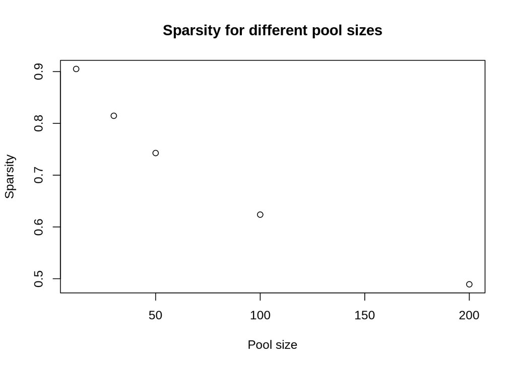

```r
plot(x=c(12,30,50,100,200), y=sparsities,
     main="Sparsity for different pool sizes",
     xlab="Pool size", ylab="Sparsity")
```

Note that for pool sizes beyond a particular size, you lose cell types as they have less than pool_size cells. In this case, I’ll use `pool_size = 100`. I use the `pool_cells_follow_cells()` function to keep track of which cells end up in which pools.

```r
pool_output <- pool_cells_follow_cells(sce, pool_size=100, keep_smaller_pools = F)
```

```
## Pooling cells per cell type with pool_size 100
## Not including cell type E5Tshz2
## Not including cell type Endo
## Not including cell type Mic
## Not including cell type OliI
## Not including cell type OPC
## Not including cell type Peri
##
## Dropout ratio: 0.624
## Cell number: 93
## Done
```

```r
pooled_sce <- pool_output[[1]]
pooled_sce_cells_in_pools <- pool_output[[2]]
```

## Adjust region sizes

In most peak regions, the TF occupies sequences around the middle of the peak. This is why to decrease runtimes and increase signal/noise, it is useful to take the middle 250 bp for each peak region.

I do this like this:

```r
peaknames <- rownames(pooled_sce)

peak_start <- as.numeric(str_remove(str_remove(peaknames, "^chr[a-zA-Z0-9]+_"), "_[0-9]+$"))
peak_end <- as.numeric(str_remove(peaknames, "^chr[a-zA-Z0-9]+_[0-9]+_"))
peak_chrom <- str_remove(peaknames, "_[0-9]+_[0-9]+$")

peak_middles <- round((peak_end+peak_start)/2)
peak_start <- peak_middles-125
peak_end <- peak_middles+124

# Create peak ranges
peak_ranges_df <- data.frame(seqnames=peak_chrom,
                              start=peak_start,
                              end=peak_end)
peak_ranges <- makeGRangesFromDataFrame(peak_ranges_df)
```

## Removing peaks that overlap promoter regions

For this particular dataset, I’m interested in finding the signals that lie in distal regulatory regions. I’m going to filter out the peaks that overlap regions between -8 kb and +0.5 kb around the transcription start sites.

For this particular dataset, I know that the `mm10` genome was used. I use AnnotationHub to find the annotation for the `mm10` genome, and I With this, I generate promoter (-8 kb to +0.5 kb around TSS) regions:

```r
ah <- AnnotationHub()
```

```
## snapshotDate(): 2019-10-29
```

```r
# Let's find mm10 annotation
query(ah, c("GRCm38", "gtf"))
```

```
## AnnotationHub with 75 records
## # snapshotDate(): 2019-10-29
## # $dataprovider: Ensembl
## # $species: Mus musculus
## # $rdataclass: GRanges
## # additional mcols(): taxonomyid, genome, description,
## #   coordinate_1_based, maintainer, rdatadateadded, preparerclass, tags,
## #   rdatapath, sourceurl, sourcetype
## # retrieve records with, e.g., 'object[["AH7567"]]'
##
##             title
##   AH7567  | Mus_musculus.GRCm38.70.gtf
##   AH7628  | Mus_musculus.GRCm38.69.gtf
##   AH7675  | Mus_musculus.GRCm38.71.gtf
##   AH7736  | Mus_musculus.GRCm38.72.gtf
##   AH7799  | Mus_musculus.GRCm38.73.gtf
##   ...       ...
##   AH75472 | Mus_musculus.GRCm38.98.gtf
##   AH79242 | Mus_musculus.GRCm38.99.abinitio.gtf
##   AH79243 | Mus_musculus.GRCm38.99.chr.gtf
##   AH79244 | Mus_musculus.GRCm38.99.chr_patch_hapl_scaff.gtf
##   AH79245 | Mus_musculus.GRCm38.99.gtf
```

```r
mm10_gtf <- ah[["AH69533"]]
```

```
## loading from cache
```

```
## Importing File into R ..
```

```
## require("rtracklayer")
```

```r
# Get unique genes in annotation
genes <- mm10_gtf[mm10_gtf$type == "gene" &
                    seqnames(mm10_gtf) %in% c(1:19, "X", "Y")]
genes <- genes[!duplicated(genes$gene_name),]

# This defines how many bp upstream and downstream of TSSs you want to extract
upstream = 8000
downstream = 500

# This returns a GRanges object:
promoter_ranges <- GenomicRanges::promoters(genes,
                                            upstream = upstream,
                                            downstream = downstream)
seqlevelsStyle(promoter_ranges) <- "UCSC"
```

Now, I’m going to identify peak regions that overlap these promoter ranges:

```r
ranges_promoter_overlap <- findOverlaps(peak_ranges, promoter_ranges, ignore.strand=F, minoverlap = 1)
ranges_overlapping_with_promoter <- unique(ranges_promoter_overlap@from)
ranges_that_overlap <- (1:length(peak_ranges) %in% ranges_overlapping_with_promoter)
```

Remove the ranges overlapping promoter ranges:

```r
# Exclude peak ranges overlapping with promoter_ranges
peak_ranges <- peak_ranges[!ranges_that_overlap]
pooled_sce <- pooled_sce[!ranges_that_overlap,]
```

Now I’ll extract the sequences from the `mm10` genome using the peak ranges. The `mm10` genome can be found on `AnnotationHub`.

```r
# Find annotation
mm10 <- ah[["AH14005"]]
```

```
## loading from cache
```

```r
# Get sequences from genome
sequences <- Biostrings::getSeq(mm10, peak_ranges)
```

See if any sequences contain “N”:

```r
has_n <- str_detect(sequences, "n|N")
print(sum(has_n))
```

```
## [1] 4
```

Remove those:

```r
sequences <- sequences[!has_n]
pooled_sce <- pooled_sce[!has_n,]
```

Let’s filter out cells/peaks with too high dropout:

```r
data <- logcounts(pooled_sce)

cell_dropouts <- colSums(data == 0) / dim(data)[1]
too_high_cell_dropouts <- cell_dropouts > 0.98
cat(sum(too_high_cell_dropouts))
```

```
## 0
```

```r
data <- data[,!too_high_cell_dropouts]
pooled_sce <- pooled_sce[,!too_high_cell_dropouts]

peak_dropouts <- rowSums(data == 0) / dim(data)[2]
too_high_peak_dropouts <- peak_dropouts > 0.98
cat(sum(too_high_peak_dropouts))
```

```
## 3730
```

```r
sequences <- sequences[!too_high_peak_dropouts]
data <- data[!too_high_peak_dropouts,]

cat("Peak list of", length(sequences), "peaks\n")
```

```
## Peak list of 192499 peaks
```

```r
cat("Number of pools:", ncol(data),"\n")
```

```
## Number of pools: 93
```

Now let’s extract the sequences and to-be-predicted values:

```r
seqs <- base::tolower(as.character(sequences))
ind <- assertr::col_concat(data, sep=",")
```

Now all that’s left is to write three tables:

1. The table containing the sequences and the to-be-predicted values
2. The table containing annotations for the different cell pools
3. The table containing information about which cell ended up in which pool

```r
dataset <- data.frame(region=rownames(data),
                      sequence=seqs,
                      ind=ind)

write.table(dataset, gzfile("SNARE_seq_Adult_pool100.tsv.gz"),
            sep="\t", row.names = F, col.names = T, quote = F)
write.table(colData(pooled_sce), "SNARE_seq_Adult_pool100_colData.tsv",
            sep="\t", row.names = T, col.names = T, quote = F)
write.table(pooled_sce_cells_in_pools, "SNARE_seq_Adult_pool100_cells_in_pools.tsv",
            sep="\t", row.names = T, col.names = T, quote = F)
```

The first file becomes the input file for the `scanem` argument `--data`, and the second file becomes the input file for the `scanem` argument `--celldata`.

The third file is so that information is not lost - this makes it possible to reproduce the pooling.